# STAT 300: Used car data project

Sanjana Kuchipudi

# Introduction and directions

The purpose of this project is to give you experience sourcing, reading, and using real data to answer research questions using simple linear regression. You should refer back to your previous homework assignments and R notebooks used in lecture for the relevant R codes. You are also encouraged to get help from your instructor and TA during office hours.

## Collaboration rules:

You may consult with up to two classmates for help with this project, but *use your own data*. If you collaborate with someone and use the same make/model/zip code, you will both receive 50% of earned points if there are two of you and 33% if there are three of you. Please identify who you collaborate with here.

**List collaborators**

## Project premise

Let’s assume you are interested in purchasing a used car and you want to use data to help you research what you could consider a ‘fair price’. Obviously, the price of a car depends on many things, including the car’s age, mileage, condition, make, and model. At this time, we only have the tools to consider one predictor variable at a time so you will be using the variable ‘age’ to predict the price of used cars.

For this project you will source a new, never seen before dataset by scraping observations from autotrader.com for a make and model of your choosing. You’ll want to ultimately have a clean dataset of at least 50 cars. Because you will likely need to eliminate some observations that are clearly errors, make sure the zip code you choose has at least 60 cars downloaded to the dataset.

To get your data, go to http://myslu.stlawu.edu/~clee/dataset/autotrader/, choose the make and model, then input a zip code. If you are choosing a more rare type of car it might be difficult to get at least 60 observations for certain zip codes. Try a zip code close to a big city like Boston (02124), Los Angeles (90010), or Chicago (60176). Save the data and choose a name for the dataset with a .csv extension. After you save the data, you should check the spreadsheet for any cases that should be deleted. For example, sometimes new cars will be included (mileage of 0), or odd entries with a price of 0 will appear. Make sure that after cleaning the data you have at least 50 observations. Note that if you are more comfortable cleaning the data in R, you are welcome to filter your dataset as part of your code.

You should have a dataset with variables ‘year’, ‘price’ (in $1,000’s), and ‘mileage’ (in 1,000’s) ready to load into R. Run the front-matter below to load your data into the workspace and load the packages you are most likely to need for this project.

```r
#add a variable that is named 'age', which is 2021 - year
used_cars$age <- 2021 - used_cars$year
```

```r
# filter observations
UsedCars <- used_cars %>%
  filter(mileage > 0) %>%
  filter(price >0)
```

```r
glimpse(UsedCars)
```

```
## Rows: 278
## Columns: 4
## $ year    <int> 2010, 2019, 2018, 2018, 2015, 2016, 2019, 2018, 2017, 2019, 20…
## $ price   <dbl> 16.998, 58.798, 46.604, 45.850, 26.961, 26.888, 59.900, 35.980…
## $ mileage <dbl> 82.078, 33.714, 57.669, 20.807, 87.231, 96.695, 22.843, 94.844…
## $ age     <dbl> 11, 2, 3, 3, 6, 5, 2, 3, 4, 2, 2, 4, 3, 3, 3, 8, 6, 2, 4, 5, 8…
```

```r
# get down to 50
set.seed(4)
UsedCars <- UsedCars[-sample(1:60,10,replace=F),]
```

```r
glimpse(UsedCars)
```

```
## Rows: 268
## Columns: 4
## $ year    <int> 2010, 2019, 2018, 2015, 2016, 2018, 2017, 2019, 2017, 2018, 20…
## $ price   <dbl> 16.998, 58.798, 45.850, 26.961, 26.888, 35.980, 48.995, 57.675…
## $ mileage <dbl> 82.078, 33.714, 20.807, 87.231, 96.695, 94.844, 67.879, 42.919…
## $ age     <dbl> 11, 2, 3, 6, 5, 3, 4, 2, 4, 3, 3, 3, 8, 6, 2, 4, 5, 8, 4, 7, 7…
```

```r
UsedCars
```

|  | year | price | mileage | age |
| --- | --- | --- | --- | --- |
| 1 | 2010 | 16.998 | 82.078 | 11 |
| 2 | 2019 | 58.798 | 33.714 | 2 |
| 4 | 2018 | 45.850 | 20.807 | 3 |
| 5 | 2015 | 26.961 | 87.231 | 6 |
| 6 | 2016 | 26.888 | 96.695 | 5 |
| 8 | 2018 | 35.980 | 94.844 | 3 |
| 9 | 2017 | 48.995 | 67.879 | 4 |
| 10 | 2019 | 57.675 | 42.919 | 2 |
| 12 | 2017 | 41.990 | 31.649 | 4 |
| 13 | 2018 | 49.858 | 29.116 | 3 |

[output cut: 258 more lines]

# Project

**Introduce your data using complete sentences.** What kind of car are you looking at? Where did these car listings come from (zip code and town)? Example:

I chose to study BMW X5s from the downtown Boston area and the zip code is 02101.

## Model: Choose

**Use R to compute each of the summary statistics below, writing them in the text next to their names.**

- average age: 4.1007463 4.101 years
- standard deviation of age: 2.3672863 2.367 years.
- average price: 41.7751306 41.775 thousands of dollars
- standard deviation of price: 13.8578111 13.858 thousands of dollars

## Average age

```r
mean(UsedCars$age)
```

```
## [1] 4.100746
```

## Standard deviation of age

```r
sd(UsedCars$age)
```

```
## [1] 2.367286
```

## Average price

```r
mean(UsedCars$price)
```

```
## [1] 41.77513
```

## Standard deviation of price

```r
sd(UsedCars$price)
```

```
## [1] 13.85781
```

**Produce a scatterplot of the relationship between age and price.**

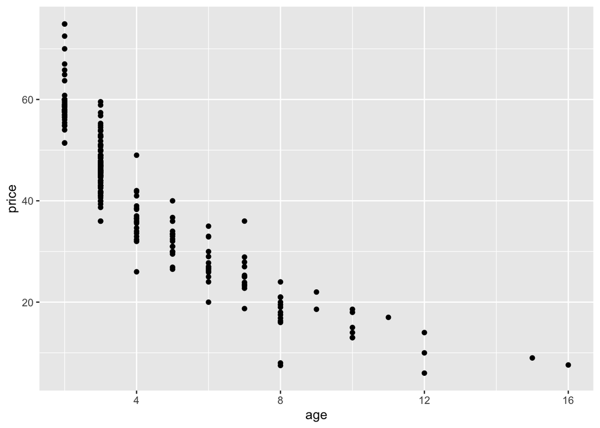

```r
gf_point(price ~ age, data = UsedCars)
```

**Using complete sentences, describe what you’ve learned from your exploratory data analysis. Make sure you are thorough, and include information about what you learned from the scatterplot.**

## Model: Fit

**Fit a simple linear model to your data.** Use R to compute each of the summary statistics below, writing them in the text next to their names.

```r
MyCarModel <- lm(price ~ age, data = UsedCars)
summary(MyCarModel)
```

```
##
## Call:
## lm(formula = price ~ age, data = UsedCars)
##
## Residuals:
##      Min       1Q   Median       3Q      Max
## -16.3105  -4.2427  -0.6433   3.8433  27.6381
##
## Coefficients:
##             Estimate Std. Error t value Pr(>|t|)
## (Intercept)  63.0777     0.7831   80.55   <2e-16 ***
## age          -5.1948     0.1655  -31.40   <2e-16 ***
## ---
## Signif. codes:  0 '***' 0.001 '**' 0.01 '*' 0.05 '.' 0.1 ' ' 1
##
## Residual standard error: 6.4 on 266 degrees of freedom
## Multiple R-squared:  0.7875, Adjusted R-squared:  0.7867
## F-statistic: 985.8 on 1 and 266 DF,  p-value: < 2.2e-16
```

```r
summary(MyCarModel)$coeff[1,1] ## estimated intercept
```

```
## [1] 63.0777
```

```r
summary(MyCarModel)$coeff[2,1] ## estimated slope
```

```
## [1] -5.194802
```

```r
summary(MyCarModel)$r.squared ## standard error of regression
```

```
## [1] 0.7874995
```

```r
anova(MyCarModel)$Sum[1] ## SSModel
```

```
## [1] 40378.56
```

```r
anova(MyCarModel)$Sum[2] ## SSError
```

```
## [1] 10895.83
```

```r
anova(MyCarModel)$Sum[1]+anova(MyCarModel)$Sum[2] ## SSTotal
```

```
## [1] 51274.39
```

**Interpret, in context, what the slope estimate tells you about age and price in your used car model. Make sure you add a sentence about why the sign (positive or negative) makes sense.**

The slope is -5.195 In context, this tells me that as age increases by 1 year, the price of the car will decrease by 5.195 thousand dollar. The negative sign makes sense because as cars get older their value decreases so therefore the price will decrease over time.

## Model: Assess

#### Residual plots

**Produce the appropriate residual plots**

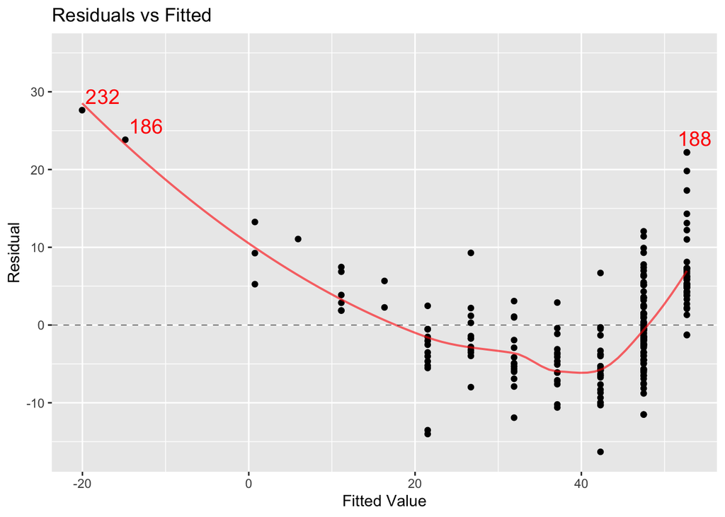

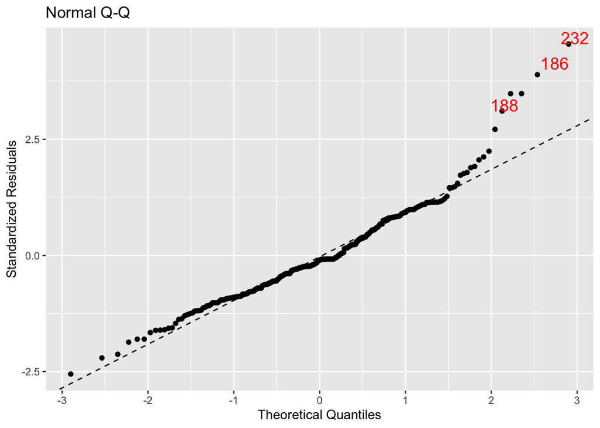

```r
mplot(MyCarModel, which = c(1,2))
```

**Comment on how well your data appear to fit the conditions for a simple linear model.** At this point, don’t worry about doing any transformations if there are problems with the conditions, just mention them.

The residual vs fitted plot shows us that the data does not fit the conditions for a simple linear model. The data is not shapeless because there is clearly a curved pattern in the data. The data is clustered on the right side together instead of distributed symmetrically. The model also doesn’t meet the condition of zero mean. there are outliers that are skewing the data and it doesn’t meet the condition of normality. The normal q-q plot shows that the line fits well but there on both sides there are outliers that don’t fit the line so it is not noramlly distributed.

#### Unusual points

```r
mod1 = lm(price ~ age, data = UsedCars)
mod1$residuals
```

```
##             1             2             4             5             6
##  11.063126323   6.109908534  -1.643289489  -4.947883559 -10.215685536
##             8             9            10            12            13
## -11.513289489   6.696512487   4.986908534  -0.308487513   2.364710511
##            14            15            16            17            18
##  -0.495289489  -1.695289489  -0.529279606  -1.931883559   4.810908534
##            19            20            21            22            23
##  -5.650487513  -7.608685536  -0.529279606  -5.299487513  -1.724081583
##            24            25            26            27            28
##   2.185918417  -2.529279606  -5.909883559 -10.303487513   9.906710511
##            29            31            32            33            34
## -14.019279606  -1.495289489  -1.248091466  -0.216289489  -5.008883559
##            35            36            37            38            39
##  -6.116685536   7.309908534  -0.074289489  -5.654289489  -8.708487513
##            40            41            42            43            45
##  -5.308487513  -0.308487513   5.153710511  19.811908534   2.531710511
##            46            47            48            49            50
##  -0.495289489  12.209908534  -5.694289489 -13.524279606  -1.298091466
##            52            55            57            59            60
##  -7.503289489  -9.348487513  -1.503289489  -3.970081583  -4.503289489
##            61            62            63            64            65
## -10.268487513   7.783710511  -3.503289489   0.205710511  -0.493487513
##            66            67            68            69            70
##  -2.816081583  -4.498289489  -3.549289489   1.501710511   3.191710511
##            71            72            73            74            75
## -10.003487513   4.306710511  -6.500487513  -6.308487513  -7.108685536
##            76            77            78            79            80
##  -1.715081583  -1.843289489  13.254928300  -3.503289489  -6.096289489
##            81            82            83            84            85
##   3.505710511  -1.993289489   6.994710511   7.301908534   3.494710511
##            86            87            88            89            90
## -11.913883559   3.504710511  -2.331289489  -3.604685536   1.501710511
##            91            92            93            94            95
##  -5.524279606  -0.495289489  -5.803487513   6.198908534  -1.818289489
##            96            97            98            99           100
##  -2.498289489   1.865324347   1.006710511  -0.643289489   2.470720394
##           101           102           103           104           105
##   5.872908534   2.096908534   5.670522370  -4.918883559  -5.870289489
##           106           107           108           109           110
##   4.309908534  -1.518289489   7.299908534  -4.158883559   6.306710511
```

[output cut: 53 more lines]

```
##  -6.505289489  27.638136206  -2.595289489  -3.219081583 -10.603685536
##           246           247           248           249           250
##   1.501710511  -0.495289489   5.211908534   1.406710511  -1.321487513
##           251           252           253           254           255
##  -2.503289489   1.306710511   0.251710511  13.111908534  -1.903289489
##           256           257           258           259           260
##   2.265522370   5.394710511  -3.993289489  -2.903289489  -5.076685536
##           261           262           263           264           265
##  -4.498289489  11.406710511   2.865324347   7.402710511  -0.703289489
##           266           267           268           269           270
##  -2.033279606   9.249928300   0.006710511   0.356710511  -2.775289489
##           271           272           273           274           275
##   5.501710511   2.891314464  -6.909883559  -7.203685536  22.199908534
##           276           277           278
##   6.860324347  -0.495289489   2.501710511
```

**Use R to find this car’s studentized residual, leverage, and Cook’s distance.** Would any of these values be considered unusual? Why or why not? Again, use complete sentences.

```r
rstandard(MyCarModel)
```

```
##            1            2            4            5            6            8
##  1.760139539  0.957857404 -0.257343374 -0.775475178 -1.599586344 -1.803010843
##            9           10           12           13           14           15
##  1.048268428  0.781803399 -0.048290468  0.370319768 -0.077563612 -0.265486709
##           16           17           18           19           20           21
## -0.083278644 -0.302781529  0.754211676 -0.884524246 -1.191378634 -0.083278644
##           22           23           24           25           26           27
## -0.829578897 -0.270650019  0.343150154 -0.397965409 -0.926248152 -1.612902339
##           28           29           31           32           33           34
##  1.551416430 -2.205840878 -0.234166192 -0.195664738 -0.033871492 -0.785035627
##           35           36           37           38           39           40
## -0.957759185  1.145982787 -0.011633926 -0.885476324 -1.363221906 -0.830987752
##           41           42           43           45           46           47
## -0.048290468  0.807084365  3.105935737  0.396472399 -0.077563612  1.914161435
##           48           49           50           52           55           57
## -0.891740428 -2.127955904 -0.203503295 -1.175034496 -1.463407158 -0.235419013
##           59           60           61           62           63           64
## -0.623231909 -0.705226754 -1.607423458  1.218949151 -0.548624174  0.032214797
##           65           66           67           68           69           70
## -0.077250267 -0.442074518 -0.704443742 -0.555827893  0.235171741  0.499830102
##           71           72           73           74           75           76
## -1.565940502  0.674441979 -1.017582785 -0.987527209 -1.113087934 -0.269237180
##           77           78           79           80           81           82
## -0.288663890  2.119751169 -0.548624174 -0.954694665  0.549003312 -0.312154278
##           83           84           85           86           87           88
##  1.095389715  1.144728618  0.547280684 -1.867247049  0.548846710 -0.365085950
##           89           90           91           92           93           94
## -0.564426708  0.235171741 -0.869208841 -0.077563612 -0.908474783  0.971810036
##           95           96           97           98           99          100
## -0.284748826 -0.391238581  0.295465138  0.157653464 -0.100740794  0.388751505
##          101          102          103          104          105          106
##  0.920702640  0.328734768  0.894891324 -0.770930047 -0.919302482  0.675669329
##          107          108          109          110          111          112
## -0.237768052  1.144415075 -0.651816262  0.987647140 -0.077250407 -0.957289441
##          113          114          115          116          117          118
## -0.780082788 -0.487545241  0.675042244 -0.077563612  2.242910542  0.044570121
##          119          120          121          122          123          124
## -0.907692086  0.827423805 -0.077563612 -0.703817331  0.831343083 -0.223830422
##          125          126          127          128          129          130
## -0.312154278 -0.239835310 -1.239705480 -1.276199763  0.425149027 -0.327814536
```

[output cut: 35 more lines]

```
## -0.249513245  0.157653464  0.295465138 -0.063209646 -1.254143136 -0.766614966
##          239          240          241          242          243          244
## -1.197916239 -0.239334078 -1.018745120  4.547816706 -0.406429031 -0.505338321
##          245          246          247          248          249          250
## -1.660339927  0.235171741 -0.077563612  0.817076909  0.220294496 -0.206864938
##          251          252          253          254          255          256
## -0.392021594  0.204634238  0.039418516  2.055569015 -0.298060045  0.357532548
##          257          258          259          260          261          262
##  0.844825587 -0.625359438 -0.454662626 -0.794914529 -0.704443742  1.786320300
##          263          264          265          266          267          268
##  0.453863938  1.159283568 -0.110136949 -0.319923092  1.479264609  0.001050883
##          269          270          271          272          273          274
##  0.055861786 -0.434617495  0.861582063  0.452726067 -1.082976816 -1.127963167
##          275          276          277          278
##  3.480305250  1.086667143 -0.077563612  0.391774321
```

```r
hatvalues(MyCarModel)[265]
```

```
##         275
## 0.006680748
```

```r
2*(2/275)
```

```
## [1] 0.01454545
```

```r
3*(2/275)
```

```
## [1] 0.02181818
```

The leverage is less than two or three times the average leverage that is according to the linear model.

## Model: Use

#### Confidence interval

**Compute and interpret a 95% confidence interval for the slope of your model.**

```r
confint(MyCarModel, level = 0.95)
```

```
##                 2.5 %    97.5 %
## (Intercept) 61.535894 64.619497
## age         -5.520572 -4.869032
```

There is a 95% chance that the true slope of the data falls between -5.521 and -4.869.

#### Coefficient of determination

**Report the coefficient of determination (r-squared) and show how it can be computed using values from the ANOVA table.**

R^2 = 1 - SSE / SST 1- (10896/(40379+10896)) = 0.787

```r
anova(MyCarModel)
```

|  | Df | Sum Sq | Mean Sq | F value | Pr(>F) |
| --- | --- | --- | --- | --- | --- |
| age | 1 | 40378.56 | 40378.55954 | 985.7618 | 1.902842e-91 |
| Residuals | 266 | 10895.83 | 40.96178 | NA | NA |

**Interpret the value in context using a complete sentence.**

The value of R^2 shows how well the regression line fits with the data. The closer it is to 1 the better of a fit it is. The value is 0.787 so the fit is fairly good.

```r
summary(MyCarModel)
```

```
##
## Call:
## lm(formula = price ~ age, data = UsedCars)
##
## Residuals:
##      Min       1Q   Median       3Q      Max
## -16.3105  -4.2427  -0.6433   3.8433  27.6381
##
## Coefficients:
##             Estimate Std. Error t value Pr(>|t|)
## (Intercept)  63.0777     0.7831   80.55   <2e-16 ***
## age          -5.1948     0.1655  -31.40   <2e-16 ***
## ---
## Signif. codes:  0 '***' 0.001 '**' 0.01 '*' 0.05 '.' 0.1 ' ' 1
##
## Residual standard error: 6.4 on 266 degrees of freedom
## Multiple R-squared:  0.7875, Adjusted R-squared:  0.7867
## F-statistic: 985.8 on 1 and 266 DF,  p-value: < 2.2e-16
```

#### Hypothesis tests

**Test the strength of the linear relationship between age and price using all three methods discussed in class.** For each of them, write the hypotheses (it’s fine to type them out without using special symbols), discuss how to calculate test statistic and show its value, indicate the reference distribution (t or F including degrees of freedom), and report the p-values. At the end, you can write one conclusion in context that reflects the conclusion based on all three p-values.

```r
cor(UsedCars$price, UsedCars$age)
```

```
## [1] -0.8874117
```

```r
anova(MyCarModel)
```

|  | Df | Sum Sq | Mean Sq | F value | Pr(>F) |
| --- | --- | --- | --- | --- | --- |
| age | 1 | 40378.56 | 40378.55954 | 985.7618 | 1.902842e-91 |
| Residuals | 266 | 10895.83 | 40.96178 | NA | NA |

#### Predictions

Suppose you are interested in purchasing a car of this make and model that is five years old. For each of quantities below, show how to complete the calculations using formulas (with the correct numbers in the correct places). For the intervals, write a sentence that carefully interprets each in terms of car prices.

```r
newdata=data.frame(age = 5)
predict.lm(MyCarModel, newdata, interval = "confidence", level = 0.9)
```

```
##        fit      lwr      upr
## 1 37.10369 36.41323 37.79414
```

```r
predict.lm(MyCarModel, newdata, interval = "prediction", level = 0.9)
```

```
##        fit      lwr      upr
## 1 37.10369 26.51706 47.69031
```

1. Predicted value for price of a car that is five years old
2. 90% confidence interval for the *mean price* of a car at this age is 37.104 thousand dollars and we are 90% confident that the mean price of a car of this model that is 5 years old falls between 36.413 and 37.794 thousand dollars.
3. 90% prediction interval for the price of an *individual* car of this age falls between 26.517 and 47.690 thousand dollars. This means we are 90% confident that the price of an individual car falls between 26.517 and 47.690 thousand dollars.

# Discussion

According to your model, is there an age at which the car should be free? If so, find out what this age is and comment on what the ‘free car phenomenon’ says about the appropriateness of your model.

```r
63.0777/5.1948
```

```
## [1] 12.14247
```

0 = -5.1948(age) + 63.0777 age = 12.142

At approximately at 12.142 years the car should be free according to my model. This shows that my model is only useful for certain ages and after a certain age the model will start making no sense. Cars do not accurately follow the rate of depreciation in this model.